# STATSII_project

Anup Bhutada, Ayush Pandey, Shouvik Sengupta, Uday Gadge

2023-05-01

## Predicting Green house emissions from Sensor data

Following is a data set collected from experiment set up to measure green house emissions from a turbine engine. There are different sensors set up to measure certain dependent features like temperature, pressure etc. The goal is to see to what extent these measurements can be useful to predict the emission of green house gases. There are two features here that measure these emissions `NOx` and `CO`.

**Reading the data**

The data is formatted year wise, so it needs to be merged.

```r
library(tidyr)
library(tidyverse)
```

```r
library(ggplot2)

path <- 'C:/Users/gadge/OneDrive/Desktop/STATS-II/Project/'
df1 <- read_csv(paste(path, 'gt_2011.csv', sep = '')) %>% mutate(year = 2011)
df2 <- read_csv(paste(path, 'gt_2012.csv', sep = '')) %>% mutate(year = 2012)
df3 <- read_csv(paste(path, 'gt_2013.csv', sep = '')) %>% mutate(year = 2013)
df4 <- read_csv(paste(path, 'gt_2014.csv', sep = '')) %>% mutate(year = 2014)
df5 <- read_csv(paste(path, 'gt_2015.csv', sep = '')) %>% mutate(year = 2014)
df <- rbind(df1, df2, df3, df4, df5)
head(df)
```

```
## # A tibble: 6 × 12
##      AT    AP    AH  AFDP  GTEP   TIT   TAT   TEY   CDP    CO   NOX  year
##   <dbl> <dbl> <dbl> <dbl> <dbl> <dbl> <dbl> <dbl> <dbl> <dbl> <dbl> <dbl>
## 1  4.59 1019.  83.7  3.58  24.0 1086.  550.  135.  11.9 0.327  82.0  2011
## 2  4.29 1018.  84.2  3.57  24.0 1086.  550.  135.  11.9 0.448  82.4  2011
## 3  3.90 1018.  84.9  3.58  24.0 1086.  550.  135.  12.0 0.451  83.8  2011
## 4  3.74 1018.  85.4  3.58  23.9 1086.  550.  135.  12.0 0.231  82.5  2011
## 5  3.75 1018.  85.2  3.58  23.9 1086.  550   135.  11.9 0.267  82.0  2011
## 6  3.89 1018.  83.9  3.58  23.9 1086   550.  135.  11.9 0.235  81.7  2011
```

```r
(colnames(df))
```

```
##  [1] "AT"   "AP"   "AH"   "AFDP" "GTEP" "TIT"  "TAT"  "TEY"  "CDP"  "CO"
## [11] "NOX"  "year"
```

```r
(dim(df))
```

```
## [1] 36733    12
```

** Data Exploration and Visualization **

The data has only numerical features.

```r
library(reshape2)
```

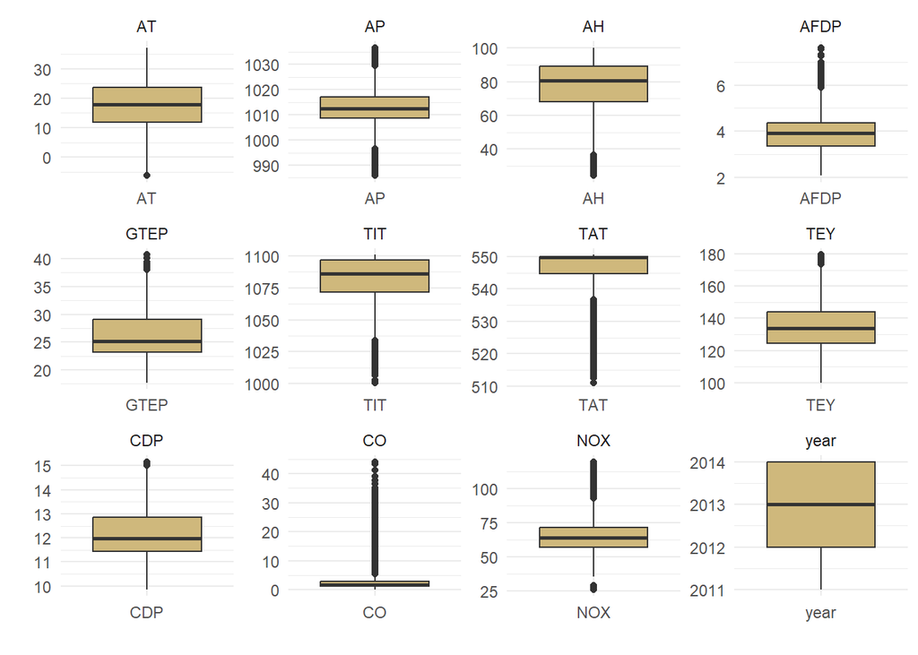

```r
p <- ggplot(melt(df), aes(factor(variable), value))
p + geom_boxplot(fill = "#CFB87C") + facet_wrap(~variable, scale="free")+xlab("")+ylab("")+
  theme_minimal()
```

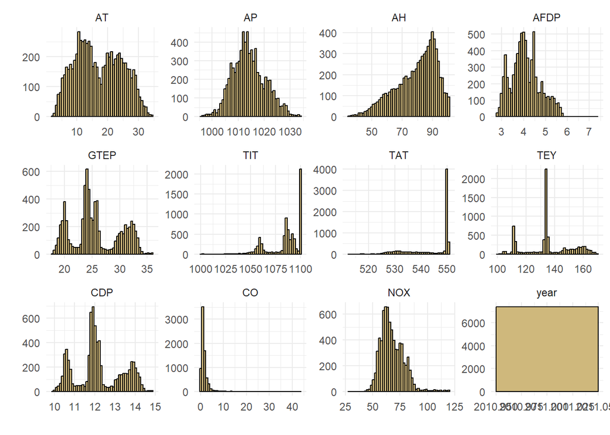

```r
library(reshape2)
p <- ggplot(melt(df1), aes(x=value))
p + geom_histogram(bins = 50, fill = "#CFB87C",col = "black") + facet_wrap(~variable, scale="free") + xlab("")+ylab("")+
  theme_minimal()
```

Exploring correlations between features

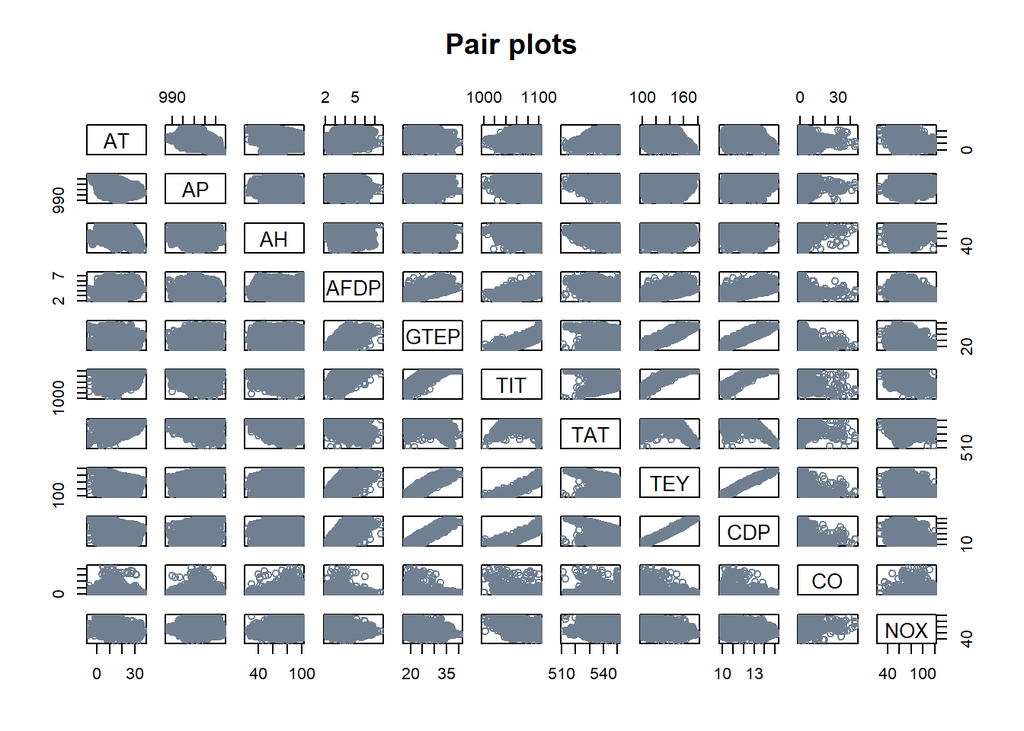

```r
pairs(df[,-12],col = "slategrey", main = "Pair plots")
```

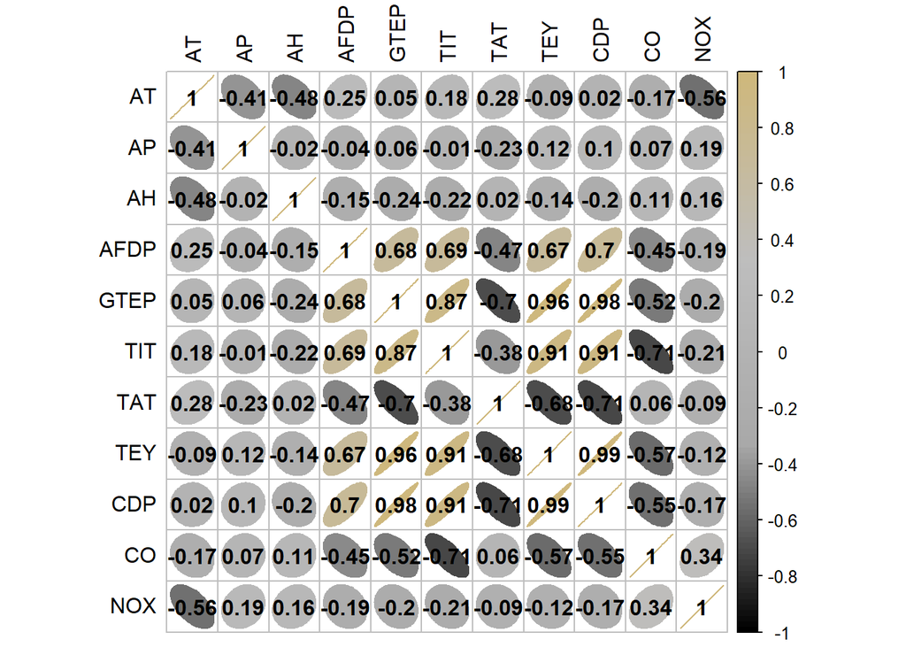

```r
library(corrplot)
col4 = colorRampPalette(c("black", "darkgrey", "grey","#CFB87C"))
corrplot(cor(df[,-12]), method = "ellipse", col = col4(100),  addCoef.col = "black", tl.col = "black")
```

There are some features with high correlation, looking at them closely.

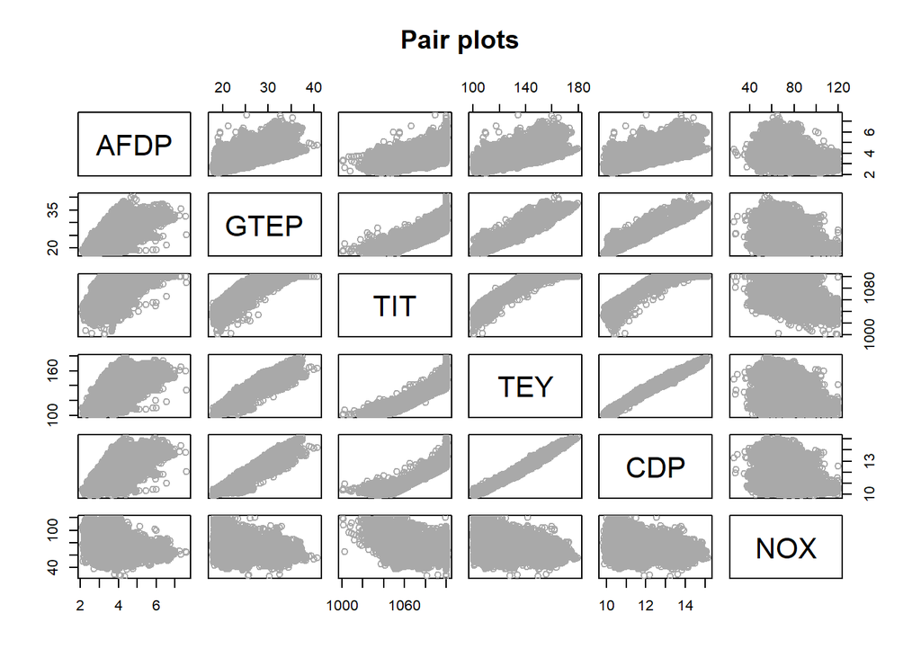

```r
pairs(df[c('AFDP', 'GTEP', 'TIT', 'TEY', 'CDP', 'NOX')], col = "darkgrey",main = "Pair plots")
```

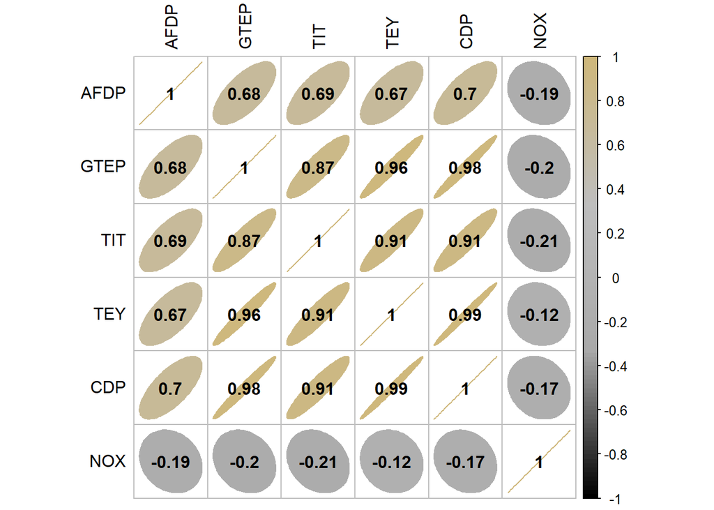

```r
library(corrplot)
col4 = colorRampPalette(c("black", "darkgrey", "grey","#CFB87C"))
corrplot(cor(df[c('AFDP', 'GTEP', 'TIT', 'TEY', 'CDP' , 'NOX')]),
         method = "ellipse", col = col4(100),  addCoef.col = "black", tl.col = "black")
```

```r
lmod <- lm(NOX ~ . - CO - year - CDP, data = df)
summary(lmod)
```

```
##
## Call:
## lm(formula = NOX ~ . - CO - year - CDP, data = df)
##
## Residuals:
##     Min      1Q  Median      3Q     Max
## -36.224  -4.815  -0.044   3.771  52.534
##
## Coefficients:
##               Estimate Std. Error  t value Pr(>|t|)
## (Intercept) -65.720771  11.374007   -5.778 7.61e-09 ***
## AT           -1.793499   0.012283 -146.020  < 2e-16 ***
## AP           -0.243939   0.007533  -32.385  < 2e-16 ***
## AH           -0.223240   0.003644  -61.269  < 2e-16 ***
## AFDP          0.686039   0.086145    7.964 1.72e-15 ***
## GTEP         -0.153111   0.053205   -2.878  0.00401 **
## TIT           1.405350   0.014903   94.300  < 2e-16 ***
## TAT          -1.497407   0.016683  -89.757  < 2e-16 ***
## TEY          -2.048221   0.026483  -77.340  < 2e-16 ***
## ---
## Signif. codes:  0 '***' 0.001 '**' 0.01 '*' 0.05 '.' 0.1 ' ' 1
##
## Residual standard error: 8.111 on 36724 degrees of freedom
## Multiple R-squared:  0.5177, Adjusted R-squared:  0.5176
## F-statistic:  4928 on 8 and 36724 DF,  p-value: < 2.2e-16
```

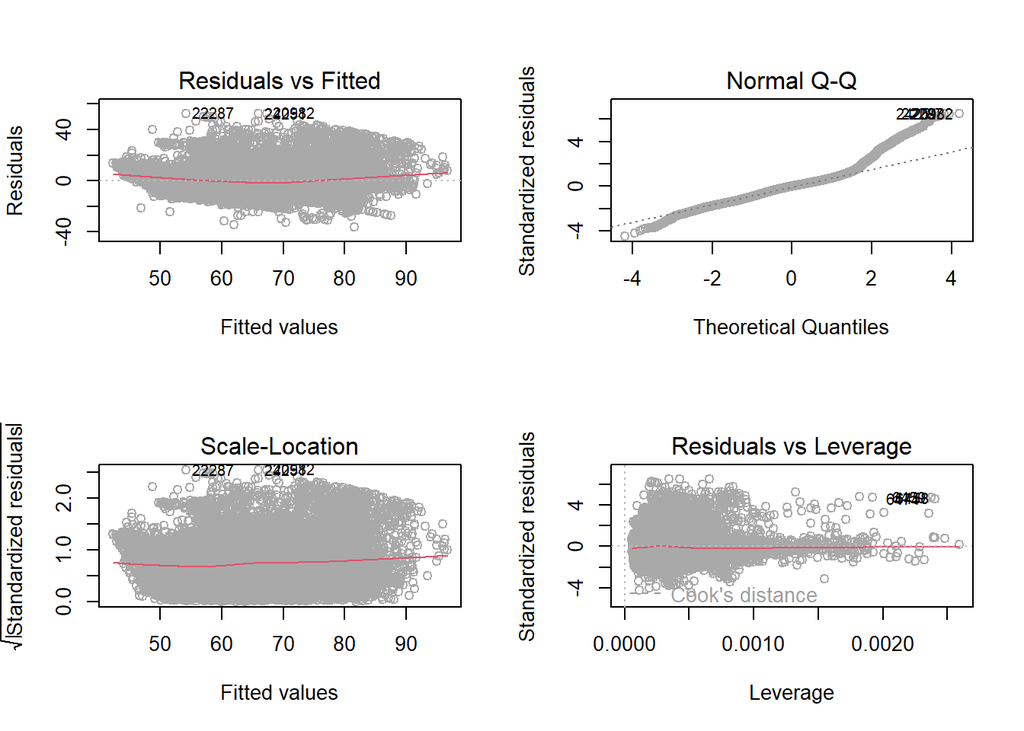

```r
par(mfrow = c(2,2))
plot(lmod,col = "darkgrey")
```

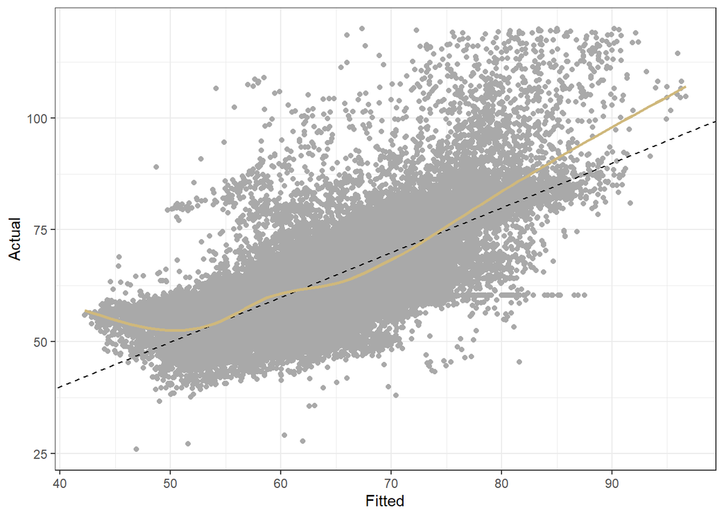

```r
ggplot(mapping = aes(fitted(lmod),df$NOX)) + geom_point(col = "darkgrey")+
  geom_abline(slope = 1, intercept = 0, col = 'black',linetype = 'dashed')+
  geom_smooth(se = FALSE, col = "#CFB87C")+theme_bw()+xlab("Fitted") + ylab("Actual")
```

From the above plots, some key violations of linear regression are:

- Normality

The histogram of `NOX` it didn’t look normal.

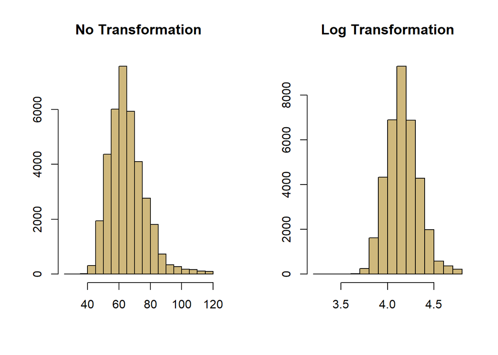

```r
par(mfrow = c(1,2))
hist(df$NOX,col = "#CFB87C",main = "No Transformation",xlab = "",ylab = "")
hist(log(df$NOX),col = "#CFB87C",main = "Log Transformation",xlab = "",ylab = "")
```

** Transformation **

The log transformation helped with normality to an extent.

```r
lm_transform = lm(log(NOX) ~ . - year - CO - CDP, data = df)
summary(lm_transform)
```

```
##
## Call:
## lm(formula = log(NOX) ~ . - year - CO - CDP, data = df)
##
## Residuals:
##      Min       1Q   Median       3Q      Max
## -0.79999 -0.06803  0.00330  0.06008  0.67087
##
## Coefficients:
##               Estimate Std. Error  t value Pr(>|t|)
## (Intercept)  1.157e+00  1.638e-01    7.061 1.68e-12 ***
## AT          -2.774e-02  1.769e-04 -156.786  < 2e-16 ***
## AP          -3.932e-03  1.085e-04  -36.241  < 2e-16 ***
## AH          -3.417e-03  5.248e-05  -65.104  < 2e-16 ***
## AFDP         1.034e-02  1.241e-03    8.333  < 2e-16 ***
## GTEP        -9.759e-04  7.664e-04   -1.273    0.203
## TIT          2.221e-02  2.147e-04  103.462  < 2e-16 ***
## TAT         -2.206e-02  2.403e-04  -91.806  < 2e-16 ***
## TEY         -3.174e-02  3.815e-04  -83.192  < 2e-16 ***
## ---
## Signif. codes:  0 '***' 0.001 '**' 0.01 '*' 0.05 '.' 0.1 ' ' 1
##
## Residual standard error: 0.1168 on 36724 degrees of freedom
## Multiple R-squared:  0.535,  Adjusted R-squared:  0.5349
## F-statistic:  5282 on 8 and 36724 DF,  p-value: < 2.2e-16
```

GTEP is insignificant

```r
lm_transform = lm(log(NOX) ~ . - year - CO - CDP - GTEP, data = df)
summary(lm_transform)
```

```
##
## Call:
## lm(formula = log(NOX) ~ . - year - CO - CDP - GTEP, data = df)
##
## Residuals:
##      Min       1Q   Median       3Q      Max
## -0.80008 -0.06793  0.00328  0.06009  0.67016
##
## Coefficients:
##               Estimate Std. Error  t value Pr(>|t|)
## (Intercept)  1.073e+00  1.501e-01    7.149 8.93e-13 ***
## AT          -2.786e-02  1.513e-04 -184.161  < 2e-16 ***
## AP          -3.922e-03  1.082e-04  -36.243  < 2e-16 ***
## AH          -3.407e-03  5.188e-05  -65.664  < 2e-16 ***
## AFDP         1.036e-02  1.241e-03    8.354  < 2e-16 ***
## TIT          2.229e-02  2.041e-04  109.225  < 2e-16 ***
## TAT         -2.205e-02  2.402e-04  -91.800  < 2e-16 ***
## TEY         -3.208e-02  2.707e-04 -118.512  < 2e-16 ***
## ---
## Signif. codes:  0 '***' 0.001 '**' 0.01 '*' 0.05 '.' 0.1 ' ' 1
##
## Residual standard error: 0.1168 on 36725 degrees of freedom
## Multiple R-squared:  0.535,  Adjusted R-squared:  0.5349
## F-statistic:  6036 on 7 and 36725 DF,  p-value: < 2.2e-16
```

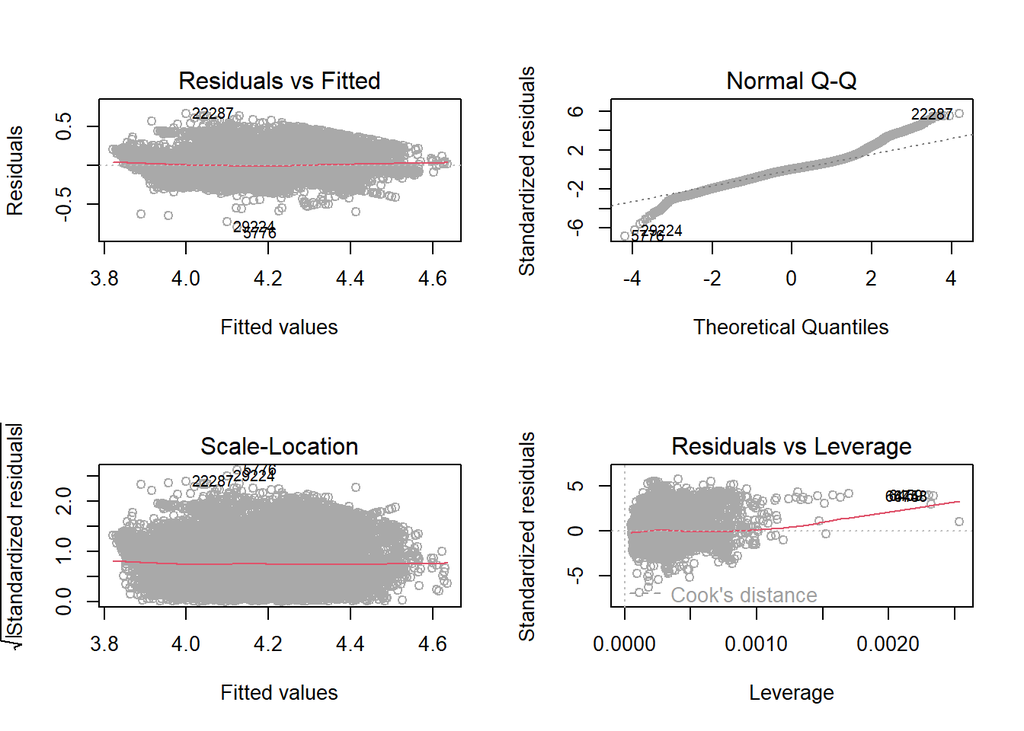

```r
par(mfrow = c(2,2))
plot(lm_transform, col = "darkgrey")
```

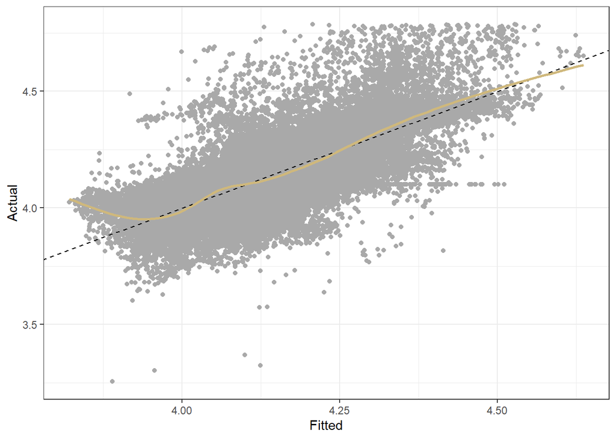

```r
ggplot(mapping = aes(fitted(lm_transform),log(df$NOX))) + geom_point(col = "darkgrey")+
  geom_abline(slope = 1, intercept = 0, col = 'black',linetype = 'dashed')+
  geom_smooth(se = FALSE, col = "#CFB87C")+theme_bw()+xlab("Fitted") + ylab("Actual")
```

Normality is a bit of an issue but not too much

** Multicolinearity check **

```r
library(car)
vif(lm_transform)
```

```
##        AT        AP        AH      AFDP       TIT       TAT       TEY
##  3.414612  1.316497  1.514730  2.481097 34.476777  7.271245 48.090956
```

There are some features with high VIF.

```r
kappa(lm_transform)
```

```
## [1] 129631.8
```

The value of kappa is also too high. The model has some variance in it.

## Model selection

We can try to remove the predictor with highest VIF value, but this caused other predictors to become insignificant. Therefore we are using a systematic approach to remove multicollinearity.

```r
library(leaps)
library(MASS)
n = dim(df)[1];
reg1 = regsubsets(log(NOX) ~ . - year - CO - CDP - GTEP, data = df)
rs = summary(reg1)
rs$which
```

```
##   (Intercept)   AT    AP    AH  AFDP   TIT   TAT   TEY
## 1        TRUE TRUE FALSE FALSE FALSE FALSE FALSE FALSE
## 2        TRUE TRUE FALSE FALSE FALSE FALSE FALSE  TRUE
## 3        TRUE TRUE FALSE FALSE FALSE  TRUE FALSE  TRUE
## 4        TRUE TRUE FALSE FALSE FALSE  TRUE  TRUE  TRUE
## 5        TRUE TRUE FALSE  TRUE FALSE  TRUE  TRUE  TRUE
## 6        TRUE TRUE  TRUE  TRUE FALSE  TRUE  TRUE  TRUE
## 7        TRUE TRUE  TRUE  TRUE  TRUE  TRUE  TRUE  TRUE
```

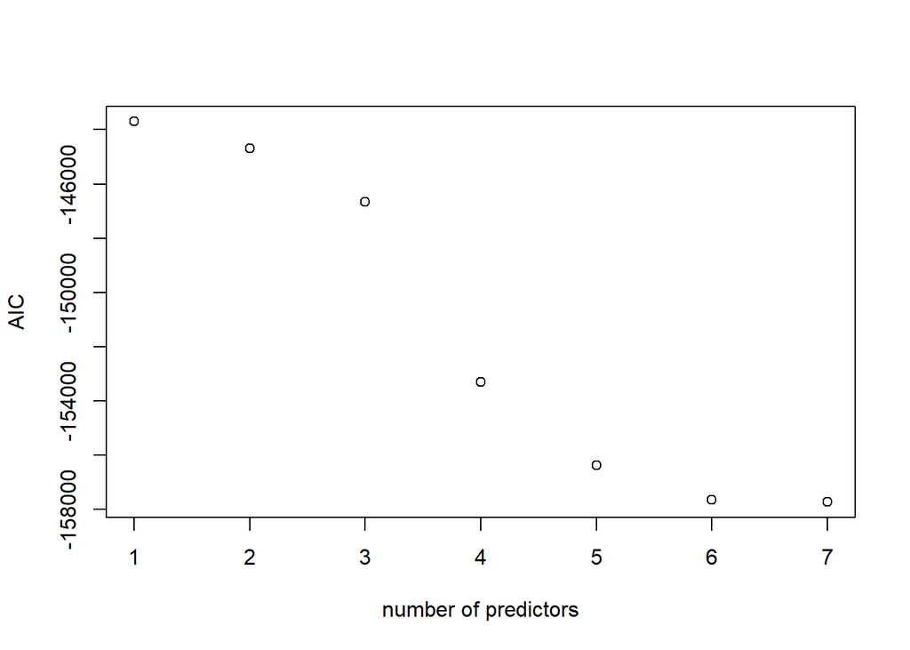

```r
AIC <- 2*(2:8) + n*log(rs$rss/n)
plot(AIC ~ I(1:7), xlab = "number of predictors", ylab = 'AIC')
```

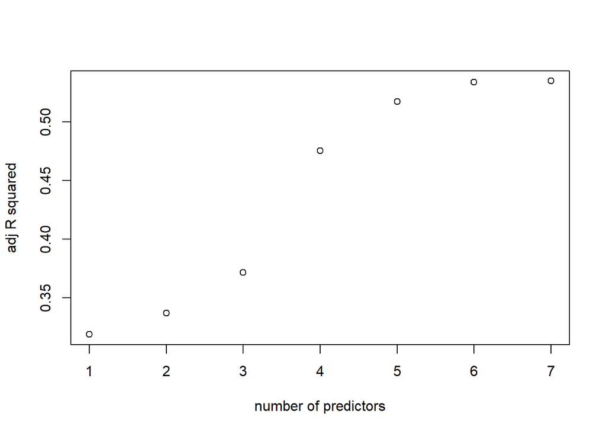

```r
plot(1:7, rs$adjr2, xlab = "number of predictors", ylab = "adj R squared")
```

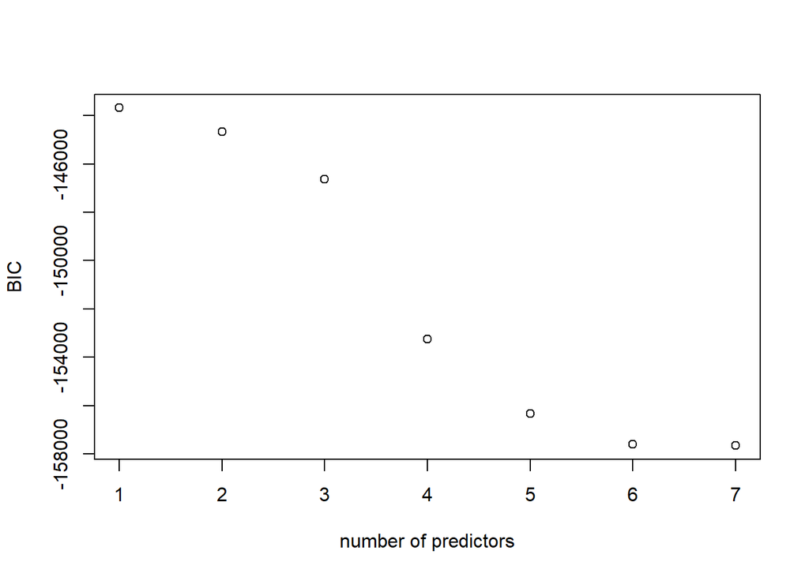

```r
BIC = log(n)*(2:8) + n*log(rs$rss/n)
plot(BIC ~ I(1:7), xlab = "number of predictors", ylab = "BIC")
```

```r
lm_6 <- lm(log(NOX) ~ . - year - CO - CDP - AFDP - GTEP, data = df)
summary(lm_6)
```

```
##
## Call:
## lm(formula = log(NOX) ~ . - year - CO - CDP - AFDP - GTEP, data = df)
##
## Residuals:
##      Min       1Q   Median       3Q      Max
## -0.80262 -0.06846  0.00386  0.06032  0.67659
##
## Coefficients:
##               Estimate Std. Error  t value Pr(>|t|)
## (Intercept)  1.009e+00  1.501e-01    6.721 1.84e-11 ***
## AT          -2.759e-02  1.481e-04 -186.279  < 2e-16 ***
## AP          -3.915e-03  1.083e-04  -36.147  < 2e-16 ***
## AH          -3.342e-03  5.135e-05  -65.086  < 2e-16 ***
## TIT          2.272e-02  1.979e-04  114.764  < 2e-16 ***
## TAT         -2.267e-02  2.290e-04  -98.966  < 2e-16 ***
## TEY         -3.233e-02  2.692e-04 -120.094  < 2e-16 ***
## ---
## Signif. codes:  0 '***' 0.001 '**' 0.01 '*' 0.05 '.' 0.1 ' ' 1
##
## Residual standard error: 0.1169 on 36726 degrees of freedom
## Multiple R-squared:  0.5341, Adjusted R-squared:  0.534
## F-statistic:  7017 on 6 and 36726 DF,  p-value: < 2.2e-16
```

```r
vif(lm_6)
```

```
##        AT        AP        AH       TIT       TAT       TEY
##  3.269032  1.316422  1.481009 32.362356  6.595912 47.486853
```

```r
kappa(lm_6)
```

```
## [1] 133957.1
```

Removal of further features would decrease the metrics, so regularization to see if we can get a model with lower variance.

** Regularization**

```r
df_norm <- df %>% mutate(NOX_log = log(NOX))
df_norm <- df_norm %>% dplyr::select(-c(NOX))

df_norm <-  as.data.frame(scale(df_norm))

lm_norm <- lm(NOX_log ~ . - year - CO - CDP - GTEP, data = df_norm)
summary(lm_norm)
```

```
##
## Call:
## lm(formula = NOX_log ~ . - year - CO - CDP - GTEP, data = df_norm)
##
## Residuals:
##     Min      1Q  Median      3Q     Max
## -4.6702 -0.3965  0.0191  0.3507  3.9118
##
## Coefficients:
##               Estimate Std. Error  t value Pr(>|t|)
## (Intercept) -7.835e-15  3.558e-03    0.000        1
## AT          -1.211e+00  6.575e-03 -184.161   <2e-16 ***
## AP          -1.480e-01  4.083e-03  -36.243   <2e-16 ***
## AH          -2.876e-01  4.379e-03  -65.664   <2e-16 ***
## AFDP         4.682e-02  5.605e-03    8.354   <2e-16 ***
## TIT          2.282e+00  2.089e-02  109.225   <2e-16 ***
## TAT         -8.808e-01  9.595e-03  -91.800   <2e-16 ***
## TEY         -2.924e+00  2.468e-02 -118.512   <2e-16 ***
## ---
## Signif. codes:  0 '***' 0.001 '**' 0.01 '*' 0.05 '.' 0.1 ' ' 1
##
## Residual standard error: 0.682 on 36725 degrees of freedom
## Multiple R-squared:  0.535,  Adjusted R-squared:  0.5349
## F-statistic:  6036 on 7 and 36725 DF,  p-value: < 2.2e-16
```

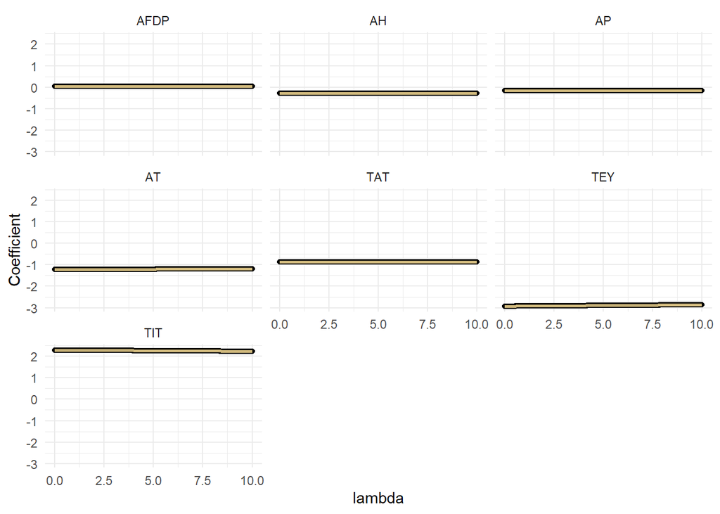

```r
lm_ridge <- lm.ridge(NOX_log ~ . - year - CO - CDP - GTEP - 1, data = df_norm, lambda = seq(0, 10, 0.01))
lm_ridge_df <- as.data.frame(t(lm_ridge$coef))
lm_ridge_df$lambda <- lm_ridge$lambda
lm_ridge_df <- lm_ridge_df%>% gather(key = "variable", value = "value", -lambda)
lm_ridge_df %>% ggplot(aes(lambda, value)) + geom_point() + geom_smooth(se = FALSE, col = "#CFB87C")+
  xlab('lambda') + ylab('Coefficient') + facet_wrap(~variable) + theme_minimal()
```

No smoothing is happening

```r
(mod <- select(lm_ridge))
```

```
## modified HKB estimator is 0.1443557
## modified L-W estimator is 4.34683
## smallest value of GCV  at 0.03
```

This suggests a lambda of 0.03 which isn’t much so regularization will not work at all.

** Correlated Errors**

```r
library(gridExtra)
```

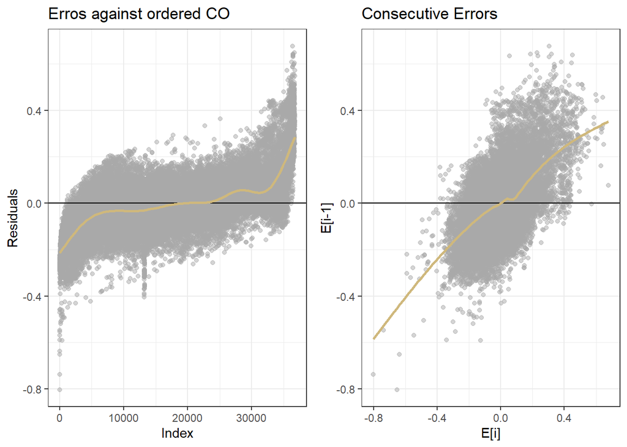

```r
ind <- order(df$NOX)
p1 <- ggplot(mapping = aes(x = 1:length(df$NOX), y = residuals(lm_6)[ind])) +
  geom_point(alpha = 0.5, col = 'darkgrey') +
  geom_abline(slope = 0, intercept = 0) +
  xlab("Index") +
  geom_smooth(se = F, col = "#CFB87C") +
  ylab("Residuals") +
  theme_bw()+ggtitle("Erros against ordered CO")

ordered.reiduals <- residuals(lm_6)[ind]
p2 <- ggplot(mapping = aes(x = ordered.reiduals[-length(ordered.reiduals)],
                           y = ordered.reiduals[-1]))+
               geom_point(alpha = 0.5, col = 'darkgrey') +
               geom_abline(slope = 0, intercept = 0) +
               xlab("E[i]") +
               geom_smooth(se = F, col = "#CFB87C") +
  ylab("E[i-1]") +
  theme_bw()+ggtitle("Consecutive Errors")

grid.arrange(p1,p2, nrow = 1)
```

```r
(cor.error <- cor(ordered.reiduals[-1],ordered.reiduals[-length(ordered.reiduals)]))
```

```
## [1] 0.5102621
```

There is some correlation in error terms. Trying Generalized Least Squares

** GLS **

```r
library(nlme)
df_ordered <- df[ind,]
df_ordered$index <- 1:length(ind)
gls.6 <- gls(log(NOX) ~ . - year - CO - CDP - GTEP - AFDP - index, data = df_ordered, correlation = corAR1(form = ~ 1 | index))
summary(gls.6)
```

```
## Generalized least squares fit by REML
##   Model: log(NOX) ~ . - year - CO - CDP - GTEP - AFDP - index
##   Data: df_ordered
##         AIC       BIC   logLik
##   -53293.34 -53216.74 26655.67
##
## Correlation Structure: AR(1)
##  Formula: ~1 | index
##  Parameter estimate(s):
## Phi
##   0
##
## Coefficients:
##                  Value  Std.Error    t-value p-value
## (Intercept)  1.0086532 0.15008459    6.72056       0
## AT          -0.0275946 0.00014814 -186.27926       0
## AP          -0.0039154 0.00010832  -36.14728       0
## AH          -0.0033421 0.00005135  -65.08612       0
## TIT          0.0227166 0.00019794  114.76420       0
## TAT         -0.0226659 0.00022903  -98.96583       0
## TEY         -0.0323311 0.00026922 -120.09373       0
##
##  Correlation:
##     (Intr) AT     AP     AH     TIT    TAT
## AT   0.095
## AP  -0.717  0.401
## AH  -0.130  0.500  0.259
## TIT -0.392 -0.672 -0.129 -0.162
## TAT  0.014  0.460  0.150  0.111 -0.827
## TEY  0.306  0.650  0.131  0.181 -0.979  0.887
##
## Standardized residuals:
##        Min         Q1        Med         Q3        Max
## -6.8632977 -0.5854347  0.0330371  0.5158221  5.7855662
##
## Residual standard error: 0.1169444
## Degrees of freedom: 36733 total; 36726 residual
```

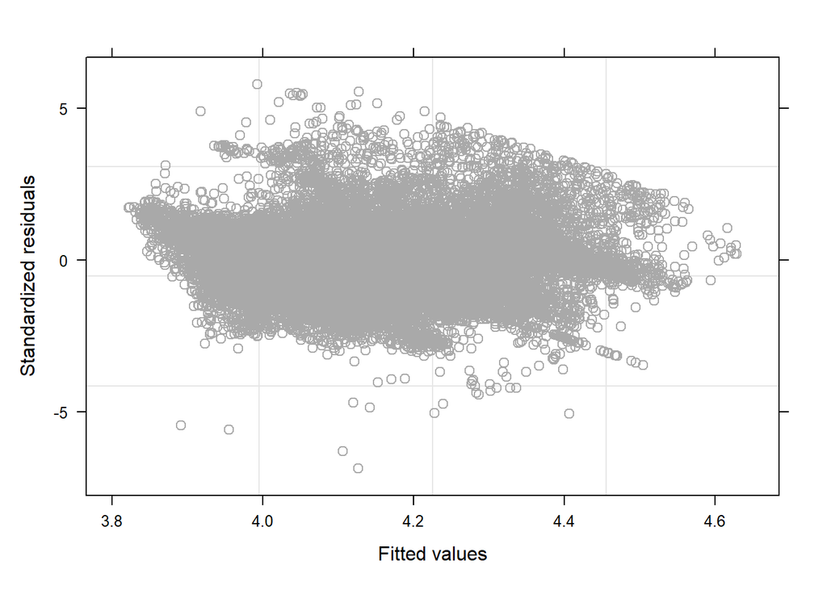

```r
plot(gls.6, col = "darkgrey")
```

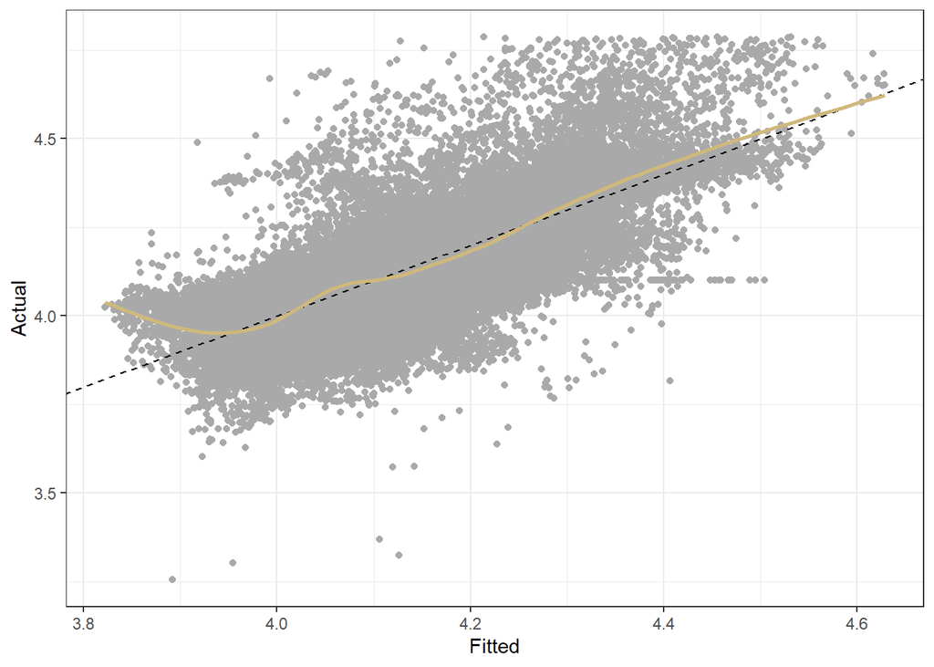

```r
ggplot(mapping = aes(x = fitted(gls.6), y = log(df_ordered$NOX))) + geom_point(col = "darkgrey")+
  geom_abline(slope = 1, intercept = 0, col = 'black',linetype = 'dashed')+
  geom_smooth(se = FALSE, col = "#CFB87C")+theme_bw()+xlab("Fitted") + ylab("Actual")
```

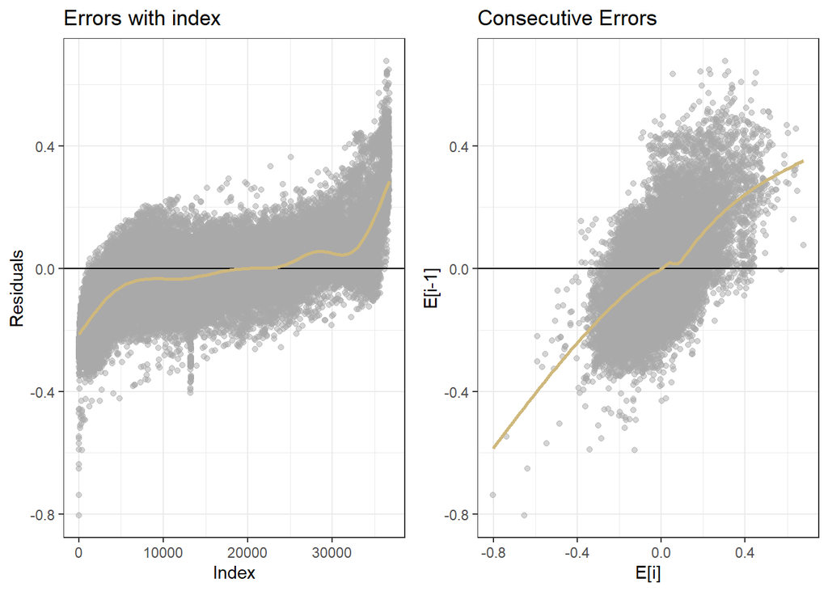

```r
p1 <- ggplot(mapping = aes(x = 1:length(df_ordered$NOX), y = residuals(gls.6))) +
  geom_point(alpha = 0.5, col = 'darkgrey') +
  geom_abline(slope = 0, intercept = 0) +
  xlab("Index") +
  geom_smooth(se = F, col = "#CFB87C") +
  ylab("Residuals") +
  theme_bw()+ggtitle("Errors with index")

ordered.reiduals <- residuals(gls.6)
p2 <- ggplot(mapping = aes(x = ordered.reiduals[-length(ordered.reiduals)],
                           y = ordered.reiduals[-1]))+
               geom_point(alpha = 0.5, col = 'darkgrey') +
               geom_abline(slope = 0, intercept = 0) +
               xlab("E[i]") +
               geom_smooth(se = F, col = "#CFB87C") +
  ylab("E[i-1]") +
  theme_bw()+ggtitle("Consecutive Errors")

grid.arrange(p1,p2, nrow = 1)
```

```r
(cor.error <- cor(ordered.reiduals[-1],ordered.reiduals[-length(ordered.reiduals)]))
```

```
## [1] 0.5102621
```

** Checking MSPEs and MAE **

For all the models try to get MSPE and MAE by splitting it into train and test split

```r
set.seed(12)
n = floor(0.8 * nrow(df1))
index = sample(seq_len(nrow(df1)), size = n)

train = df1[index, ]
test = df1[-index, ]
head(train)
```

```
## # A tibble: 6 × 12
##      AT    AP    AH  AFDP  GTEP   TIT   TAT   TEY   CDP    CO   NOX  year
##   <dbl> <dbl> <dbl> <dbl> <dbl> <dbl> <dbl> <dbl> <dbl> <dbl> <dbl> <dbl>
## 1 29.8  1006.  52.5  3.30  21.1 1064.  550.  113.  11.0 1.16   53.0  2011
## 2 23.9  1012.  67.9  4.49  31.1 1100   536.  151.  13.5 0.331  55.3  2011
## 3 33.8  1009.  47.0  4.50  29.7 1100.  542.  145.  13.0 0.168  56.6  2011
## 4  5.10 1027.  80.5  5.48  33.6 1100.  523   168.  14.5 1.75   66.0  2011
## 5 26.9  1015.  55.9  3.03  20.0 1060.  550.  111.  10.6 3.04   58.8  2011
## 6  9.81 1018.  82.3  4.24  30.3 1100.  533.  159.  13.7 1.29   64.8  2011
```

```r
summary(train)
```

```
##        AT               AP             AH              AFDP
##  Min.   : 2.116   Min.   : 996   Min.   : 35.11   Min.   :2.779
##  1st Qu.:10.928   1st Qu.:1010   1st Qu.: 70.30   1st Qu.:3.657
##  Median :16.253   Median :1014   Median : 82.19   Median :4.031
##  Mean   :17.051   Mean   :1014   Mean   : 79.21   Mean   :4.096
##  3rd Qu.:23.347   3rd Qu.:1018   3rd Qu.: 89.84   3rd Qu.:4.480
##  Max.   :34.532   Max.   :1034   Max.   :100.17   Max.   :6.983
##       GTEP            TIT            TAT             TEY
##  Min.   :17.88   Min.   :1001   Min.   :512.6   Min.   :100.2
##  1st Qu.:23.42   1st Qu.:1083   1st Qu.:538.7   1st Qu.:132.1
##  Median :24.78   Median :1088   Median :549.9   Median :133.8
##  Mean   :25.68   Mean   :1085   Mean   :544.6   Mean   :135.9
##  3rd Qu.:29.83   3rd Qu.:1100   3rd Qu.:550.0   3rd Qu.:148.3
##  Max.   :35.97   Max.   :1101   Max.   :550.6   Max.   :170.0
##       CDP               CO                NOX              year
##  Min.   : 9.904   Min.   : 0.00039   Min.   : 43.27   Min.   :2011
##  1st Qu.:11.708   1st Qu.: 0.72435   1st Qu.: 60.38   1st Qu.:2011
##  Median :12.011   Median : 1.14715   Median : 65.63   Median :2011
##  Mean   :12.213   Mean   : 1.56313   Mean   : 67.70   Mean   :2011
##  3rd Qu.:13.247   3rd Qu.: 1.73620   3rd Qu.: 74.48   3rd Qu.:2011
##  Max.   :14.851   Max.   :43.62200   Max.   :119.32   Max.   :2011
```

```r
dim(train)
```

```
## [1] 5928   12
```

Model with the 6 predictors

```r
lm_mspe_6 <- lm(log(NOX) ~ AT + AP + AH + TIT + TAT + TEY, data = train)
summary(lm_mspe_6)
```

```
##
## Call:
## lm(formula = log(NOX) ~ AT + AP + AH + TIT + TAT + TEY, data = train)
##
## Residuals:
##      Min       1Q   Median       3Q      Max
## -0.48602 -0.03794  0.00666  0.04337  0.53222
##
## Coefficients:
##               Estimate Std. Error t value Pr(>|t|)
## (Intercept) -0.1165937  0.3729817  -0.313    0.755
## AT          -0.0249797  0.0005671 -44.049  < 2e-16 ***
## AP          -0.0010784  0.0002682  -4.021 5.87e-05 ***
## AH          -0.0038216  0.0001205 -31.721  < 2e-16 ***
## TIT          0.0140392  0.0011727  11.972  < 2e-16 ***
## TAT         -0.0115539  0.0013233  -8.731  < 2e-16 ***
## TEY         -0.0205891  0.0016101 -12.787  < 2e-16 ***
## ---
## Signif. codes:  0 '***' 0.001 '**' 0.01 '*' 0.05 '.' 0.1 ' ' 1
##
## Residual standard error: 0.09412 on 5921 degrees of freedom
## Multiple R-squared:  0.6088, Adjusted R-squared:  0.6084
## F-statistic:  1536 on 6 and 5921 DF,  p-value: < 2.2e-16
```

```r
log_NOX <- predict(lm_mspe_6, newdata = test[, c('AT','AP','AH', 'TIT', 'TAT', 'TEY')])
pred_NOX <- exp(log_NOX)
length(pred_NOX)
```

```
## [1] 1483
```

```r
mspe <- mean((pred_NOX - test$NOX)^2)
mspe
```

```
## [1] 54.34963
```

```r
mae <- mean(abs(pred_NOX - test$NOX))
mae
```

```
## [1] 4.534151
```

** GLS **

```r
library(nlme)
ind <- order(train$NOX)
train_ordered <- train[ind,]
train_ordered$index <- 1:length(ind)
gls.6 <- gls(log(NOX) ~ AT + AH + AP + TIT + TAT + TEY - index, data = train_ordered,
             correlation = corAR1(form = ~ 1 | index))
summary(gls.6)
```

```
## Generalized least squares fit by REML
##   Model: log(NOX) ~ AT + AH + AP + TIT + TAT + TEY - index
##   Data: train_ordered
##         AIC       BIC  logLik
##   -11081.94 -11021.76 5549.97
##
## Correlation Structure: AR(1)
##  Formula: ~1 | index
##  Parameter estimate(s):
## Phi
##   0
##
## Coefficients:
##                   Value Std.Error   t-value p-value
## (Intercept) -0.11659369 0.3729817  -0.31260  0.7546
## AT          -0.02497970 0.0005671 -44.04874  0.0000
## AH          -0.00382163 0.0001205 -31.72099  0.0000
## AP          -0.00107840 0.0002682  -4.02093  0.0001
## TIT          0.01403917 0.0011727  11.97170  0.0000
## TAT         -0.01155388 0.0013233  -8.73113  0.0000
## TEY         -0.02058913 0.0016101 -12.78719  0.0000
##
##  Correlation:
##     (Intr) AT     AH     AP     TIT    TAT
## AT   0.350
## AH  -0.234  0.301
## AP  -0.394  0.610  0.283
## TIT -0.585 -0.895 -0.013 -0.434
## TAT  0.494  0.879  0.013  0.447 -0.984
## TEY  0.556  0.898  0.026  0.438 -0.997  0.991
##
## Standardized residuals:
##         Min          Q1         Med          Q3         Max
## -5.16374288 -0.40307649  0.07075425  0.46083701  5.65464030
##
## Residual standard error: 0.09412083
## Degrees of freedom: 5928 total; 5921 residual
```

```r
y.pred <- as.matrix(cbind(1,test %>% dplyr::select(c("AT","AH","AP","TIT","TAT","TEY")))) %*% gls.6$coefficients
y.pred <- exp(y.pred)
```

```r
mspe <- mean((test$NOX - y.pred)^2)
mspe
```

```
## [1] 54.34963
```

```r
mae <- mean(abs(test$NOX - y.pred))
mae
```

```
## [1] 4.534151
```